# Initialization

- We loaded necessary Python packages which were used for the data analysis.

```python
import numpy as np
import matplotlib.pyplot as plt
import seaborn as sns
import pandas as pd
from pyfasta import Fasta
from scipy.stats import mannwhitneyu
```

## Loading data

- The number of loops of H3K27ac GM12878 cell line with 5k resolution is **827288**. The data of `loop_info.csv` could be downloaded from [DOWNLOAD](http://health.tsinghua.edu.cn/hichipdb/download/fithichip_5k/all_info/loop_info.tar.gz) page.

```python
#wget http://health.tsinghua.edu.cn/hichipdb/download/fithichip_5k/all_info/loop_info.tar.gz && tar -zxvf loop_info.tar.gz
```

```python
df_all_loops = pd.read_csv('loop_info.csv', header=0)
df_gm12878_loops = df_all_loops.loc[(df_all_loops['cellLine'] == 'GM12878') & (df_all_loops['ChIP'] == 'H3K27ac')]
df_gm12878_loops.head()
```

|  | id | anchor1ID | anchor1 | anchor1Symbol | anchor1SnpAllele | anchor1Snp | anchor2ID | anchor2 | anchor2Symbol | anchor2SnpAllele | ... | count | qValue | normCount | geoID | sampleID | ChIP | tissue | organ | cellLine | pipeline |
| --- | --- | --- | --- | --- | --- | --- | --- | --- | --- | --- | --- | --- | --- | --- | --- | --- | --- | --- | --- | --- | --- |
| 0 | 0 | 166304 | chr1:710000-715000 | LOC100288069 | NaN | NaN | 172509 | chr1:740000-745000 | NaN | NaN | ... | 29 | 3.900000e-14 | 0.010214 | GSE101498 | GM12878_AC | H3K27ac | Blood | Blood | GM12878 | fithichip_5k |
| 1 | 1 | 166304 | chr1:710000-715000 | LOC100288069 | NaN | NaN | 175869 | chr1:755000-760000 | NaN | NaN | ... | 26 | 1.537300e-12 | 0.009158 | GSE101498 | GM12878_AC | H3K27ac | Blood | Blood | GM12878 | fithichip_5k |
| 2 | 2 | 166304 | chr1:710000-715000 | LOC100288069 | NaN | NaN | 177080 | chr1:760000-765000 | LINC00115 | NaN | ... | 37 | 7.515246e-19 | 0.013032 | GSE101498 | GM12878_AC | H3K27ac | Blood | Blood | GM12878 | fithichip_5k |
| 3 | 3 | 166304 | chr1:710000-715000 | LOC100288069 | NaN | NaN | 178258 | chr1:765000-770000 | NaN | rs2977608-A,rs2977608-C | ... | 12 | 9.601556e-05 | 0.004227 | GSE101498 | GM12878_AC | H3K27ac | Blood | Blood | GM12878 | fithichip_5k |
| 4 | 4 | 166304 | chr1:710000-715000 | LOC100288069 | NaN | NaN | 181883 | chr1:780000-785000 | NaN | rs141175086-C | ... | 11 | 4.416522e-05 | 0.003874 | GSE101498 | GM12878_AC | H3K27ac | Blood | Blood | GM12878 | fithichip_5k |

5 rows × 21 columns

# Length distribution

- The length of loop in H3K27ac GM12878 cell line is between 20~2000 kb.

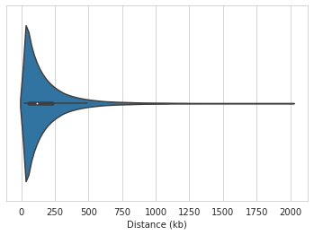

```python
df_gm12878_loops['Distance (kb)'] = (df_gm12878_loops['anchor2'].apply(lambda x: int(x.split('-')[1]))-
                                     df_gm12878_loops['anchor1'].apply(lambda x: int(x.split('-')[1])))/1000
sns.set_style("whitegrid")
#print(min(df_gm12878_loops['Distance (kb)']),max(df_gm12878_loops['Distance (kb)']))
ax = sns.violinplot(x=df_gm12878_loops["Distance (kb)"])
plt.show()
```

# Coding gene distance

## Preparing annotation data

- The coding gene information was downloaded from [GENCODE](https://www.gencodegenes.org/human/release_19.html#).

```python
#! wget https://ftp.ebi.ac.uk/pub/databases/gencode/Gencode_human/release_19/gencode.v19.annotation.gtf.gz && gunzip gencode.v19.annotation.gtf.gz
```

- Extracting the information of protein coding gene

```python
df_hg19 = pd.read_csv('gencode.v19.annotation.gtf', header=None,
                    sep='\t', skiprows=5, on_bad_lines='skip')
df_coding_genes = df_hg19.loc[(df_hg19[2]=='gene') \
                    &(['protein_coding' in item for item in df_hg19[8]]), [0,3,4,8]]
df_coding_genes[8]=df_coding_genes[8].apply(lambda x: x.split(';')[4].split(' ')[2].strip('"'))
df_coding_genes.rename(columns={0:'chrom',3:'start',4:'end',8:'protein_coding_gene_name'},inplace=True)
df_coding_genes.head()
```

|  | chrom | start | end | protein_coding_gene_name |
| --- | --- | --- | --- | --- |
| 109 | chr1 | 69091 | 70008 | OR4F5 |
| 141 | chr1 | 134901 | 139379 | AL627309.1 |
| 277 | chr1 | 367640 | 368634 | OR4F29 |
| 374 | chr1 | 621059 | 622053 | OR4F16 |
| 511 | chr1 | 738532 | 739137 | AL669831.1 |

## Distance to the nearest gene

```python
df_left_anchors = df_gm12878_loops[['anchor1']].drop_duplicates()
df_right_anchors = df_gm12878_loops[['anchor2']].drop_duplicates()
df_left_anchors['nearest_gene_distance'] = df_left_anchors['anchor1'].apply(lambda x: \
                (df_coding_genes.loc[df_coding_genes['chrom']== \
                x.split(':')[0]]['start']-int(x.split(':')[1].split('-')[0])).abs().min())
df_right_anchors['nearest_gene_distance'] = df_right_anchors['anchor2'].apply(lambda x: \
                (df_coding_genes.loc[df_coding_genes['chrom']== \
                x.split(':')[0]]['start']-int(x.split(':')[1].split('-')[0])).abs().min())
print('Median distance between left anchor and nearest gene is  %d bp.'\
                %(df_left_anchors['nearest_gene_distance'].median()))
print('Median distance between right anchor and nearest gene is  %d bp.'\
                %(df_right_anchors['nearest_gene_distance'].median()))
```

```
Median distance between left anchor and nearest gene is  39457 bp.
Median distance between right anchor and nearest gene is  39830 bp.
```

- Plot the nearest coding gene distance of left and right anchor.

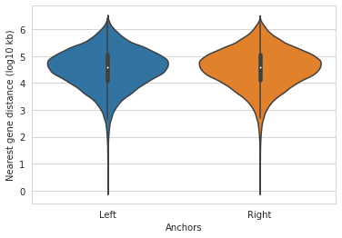

```python
df_left_anchors.rename(columns={'anchor1':'location'},inplace=True)
df_right_anchors.rename(columns={'anchor2':'location'},inplace=True)
df_left_anchors['anchor'] ='Left'
df_right_anchors['anchor'] ='Right'
df_combine_anchors=pd.concat([df_left_anchors,df_right_anchors],axis=0)
df_combine_anchors['nearest_gene_distance'] = np.log10(1+df_combine_anchors['nearest_gene_distance'])
ax = sns.violinplot(x="anchor", y="nearest_gene_distance", data=df_combine_anchors)
plt.xlabel('Anchors')
plt.ylabel('Nearest gene distance (log10 kb)')
plt.show()
```

- Next, we explore whether the distance distribution is different in left and right anchor.

```python
p_value = mannwhitneyu(df_left_anchors['nearest_gene_distance'], \
                      df_right_anchors['nearest_gene_distance'],
                      alternative='two-sided')[1]
print('The distance distribution of left and right anchor are not statistically different, two-sided Mann-Whitney U test P-value=%.4f'%p_value)
```

[output not shown]

# GC content analysis

## Preparing the data

- We need to download genome sequence data ([link](http://hgdownload.cse.ucsc.edu/goldenpath/hg19/bigZips/)) for GC content analysis.

```python
#! #wget http://hgdownload.cse.ucsc.edu/goldenpath/hg19/bigZips/hg19.fa.gz && gunzip hg19.fa.gz
```

- Calculating the GC content of loop anchors.

```python
genome = Fasta('hg19.fa')
df_left_anchors['GC_content'] = df_left_anchors['location'].apply(\
                                lambda x: (genome[x.split(':')[0]][int(x.split(':')[1].split('-')[0]):\
                                int(x.split(':')[1].split('-')[1])].upper().count('C')+\
                                genome[x.split(':')[0]][int(x.split(':')[1].split('-')[0]):\
                                int(x.split(':')[1].split('-')[1])].upper().count('G'))/ \
                                (int(x.split(':')[1].split('-')[1])-int(x.split(':')[1].split('-')[0])))
df_right_anchors['GC_content'] = df_right_anchors['location'].apply(\
                                lambda x: (genome[x.split(':')[0]][int(x.split(':')[1].split('-')[0]):\
                                int(x.split(':')[1].split('-')[1])].upper().count('C')+\
                                genome[x.split(':')[0]][int(x.split(':')[1].split('-')[0]):\
                                int(x.split(':')[1].split('-')[1])].upper().count('G'))/ \
                                (int(x.split(':')[1].split('-')[1])-int(x.split(':')[1].split('-')[0])))
print('GC content of left anchor is around %.2f to %.2f.'\
                %(df_left_anchors['GC_content'].min(),
                df_left_anchors['GC_content'].max()))
print('GC content of right anchor is around %.2f to %.2f.'\
                %(df_right_anchors['GC_content'].min(),
                df_right_anchors['GC_content'].max()))
```

```
GC content of left anchor is around 0.02 to 0.74.
GC content of right anchor is around 0.02 to 0.74.
```

## GC content distribution

- Plot the GC content of left and right anchor

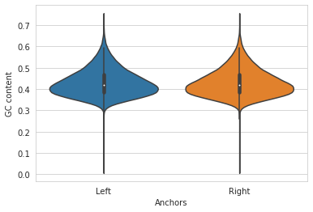

```python
df_combine_anchors=pd.concat([df_left_anchors,df_right_anchors],axis=0)
ax = sns.violinplot(x="anchor", y="GC_content", data=df_combine_anchors)
plt.xlabel('Anchors')
plt.ylabel('GC content')
plt.show()
```

- Next, we explore whether the GC content is different in left and right anchor.

```python
p_value = mannwhitneyu(df_left_anchors['GC_content'], \
                      df_right_anchors['GC_content'],
                      alternative='two-sided')[1]
print('The GC content in left and right anchor is not statistically different by two-sided Mann-Whitney U test, P-value = %.4f'%p_value)
```

```
The GC content in left and right anchor is not statistically different by two-sided Mann-Whitney U test, P-value = 0.8625
```

# Specificity analysis across cell line

- We explore the cell type specificity of the loops from HiChIP CTCF experiments on GM12878 cell line. Some loops only exist in a few cell lines (high specificity) while some loops exist in most of the cell lines (low specificity).
- We first extracted the unique and significant loops of HiChIP CTCF across diverse cell lines.

```python
all_loops_CTCF = df_all_loops.loc[(df_all_loops['ChIP'] == 'CTCF')&\
                                    (df_all_loops['qValue']<1e-10)]
all_uniq_loops = all_loops_CTCF[['anchor1','anchor2']].drop_duplicates()
```

```python
nb_cl_by_loop = []
for i in range(len(all_uniq_loops)):
    anchor1, anchor2 = all_uniq_loops.iloc[i].values
    celllines = all_loops_CTCF.loc[(all_loops_CTCF['anchor1']==anchor1)&\
                         (all_loops_CTCF['anchor2']==anchor2)]['cellLine'].values
    uniq_cellines = np.unique(celllines)
    nb_cl_by_loop.append(len(uniq_cellines))
all_uniq_loops['nb_celllines'] = nb_cl_by_loop
all_uniq_loops['specificity']=all_uniq_loops['nb_celllines'].apply(lambda x: 'Rare loops' if x < 5 else ('Others' if x < 10 else 'Common loops'))
all_uniq_loops.head()
```

[output not shown]

- Finally, we plotted the distribution of number of cell lines that a loop exist grouped by cell line specificity.

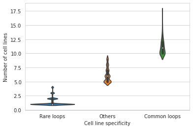

```python
ax = sns.violinplot(x="specificity", y="nb_celllines", data=all_uniq_loops)
plt.xlabel('Cell line specificity')
plt.ylabel('Number of cell lines')
plt.show()
```

# Annotating GWAS risk genes with HiChIP

- we illustrate the effectiveness of HiChIPdb through an application of annotating GWAS risk genes by using HiChIP loops
- In brief, we sum the weighted effect size from GWAS summary statistics of all genetic variants that fall on the regions that have interactions (HiChIP loops) with the target risk gene as the HiChIP annotated gene score (HAGS)
- we took the$-log_{10}(P)\times \beta$ as the as the weighted effect size for each variant where β and p is the p-value and effect size in the original GWAS study

## Loading HiChIP annotated gene score (HAGS)

- The HAGS across 95 cell types and 20242 genes were directly provided through ([link](https://health.tsinghua.edu.cn/hichipdb/tutorial/df_g_scores_minusLogPMultiBeta.csv.gz)). Users can also refer to a detailed [IPython notebook](https://health.tsinghua.edu.cn/hichipdb/tutorial/CalculateGeneScore.ipynb.gz) for how to calculate the HAGS.
- The rows and columns of HAGS file corresponds to cell types and coding genes.
- Note that -1 denotes HAGS does not exist as there is no corresponding GWAS SNPs fell into any region that has interaction with the target gene.

```python
#!wget xxx/df_g_scores_minusLogPMultiBeta.csv
df_g_scores_minusLogPMultiBeta = pd.read_csv('./GWAS_tutorial/df_g_scores_minusLogPMultiBeta_2.csv',index_col=0)
df_g_scores_minusLogPMultiBeta.head()
```

|  | SAMD11 | AL627309.1 | OR4F29 | OR4F16 | AL669831.1 | AL645608.2 | OR4F5 | AL645608.1 | NOC2L | KLHL17 | ... | MT-CO2 | MT-ATP8 | MT-ATP6 | MT-CO3 | MT-ND3 | MT-ND4L | MT-ND4 | MT-ND5 | MT-ND6 | MT-CYB |
| --- | --- | --- | --- | --- | --- | --- | --- | --- | --- | --- | --- | --- | --- | --- | --- | --- | --- | --- | --- | --- | --- |
| GM12878 | 14.972468 | -1.0 | -1.0 | -1.0 | -1.0 | -1.0 | -1.0 | -1.0 | 22.347058 | 18.342831 | ... | -1.0 | -1.0 | -1.0 | -1.0 | -1.0 | -1.0 | -1.0 | -1.0 | -1.0 | -1.0 |
| HCASMC | 108.275940 | -1.0 | -1.0 | -1.0 | -1.0 | -1.0 | -1.0 | -1.0 | 77.765512 | 68.883453 | ... | -1.0 | -1.0 | -1.0 | -1.0 | -1.0 | -1.0 | -1.0 | -1.0 | -1.0 | -1.0 |
| K562 | 155.749202 | -1.0 | -1.0 | -1.0 | -1.0 | -1.0 | -1.0 | -1.0 | 172.801196 | 175.609158 | ... | -1.0 | -1.0 | -1.0 | -1.0 | -1.0 | -1.0 | -1.0 | -1.0 | -1.0 | -1.0 |
| MyLa | 32.772657 | -1.0 | -1.0 | -1.0 | -1.0 | -1.0 | -1.0 | -1.0 | 24.225311 | 54.178839 | ... | -1.0 | -1.0 | -1.0 | -1.0 | -1.0 | -1.0 | -1.0 | -1.0 | -1.0 | -1.0 |
| Naive T primary cell | -1.000000 | -1.0 | -1.0 | -1.0 | -1.0 | -1.0 | -1.0 | -1.0 | 41.037192 | 12.642316 | ... | -1.0 | -1.0 | -1.0 | -1.0 | -1.0 | -1.0 | -1.0 | -1.0 | -1.0 | -1.0 |

5 rows × 20242 columns

## Annotated GWAS risk genes in HAEC heart cell line

- Two risk genes (NOS1AP and KCNH2) reported in literatures ([Circulation 2022](https://www.ahajournals.org/doi/10.1161/CIRCULATIONAHA.121.057261), [Circulation 2007](https://www.ahajournals.org/doi/10.1161/circulationaha.106.676783), and [Circulation 2007](https://www.ahajournals.org/doi/10.1161/circulationaha.107.710780)) were ranked $1^{st}$ and $12^{th}$ in HAEC heart cell line.

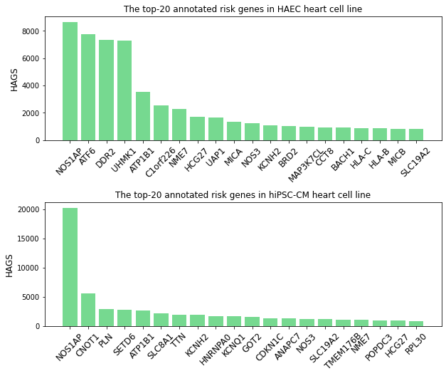

```
['NOS1AP ranked 1 in HAEC cell line', 'KCNH2 ranked 12 in HAEC cell line']
['NOS1AP ranked 1 in hiPSC-CM cell line', 'KCNH2 ranked 8 in hiPSC-CM cell line']
```

```python
n_top = 20
df_HAEC_scores = df_g_scores_minusLogPMultiBeta.loc['HAEC'].sort_values(ascending=False)
df_hiPSC_scores = df_g_scores_minusLogPMultiBeta.loc['hiPSC-CM'].sort_values(ascending=False)
HAEC_scores = df_HAEC_scores.values[:n_top]
hiPSC_scores = df_hiPSC_scores.values[:n_top]
HAEC_genes_names = df_HAEC_scores.index.to_list()[:n_top]
hiPSC_genes_names = df_hiPSC_scores.index.to_list()[:n_top]
x_pos = [i for i, _ in enumerate(HAEC_scores)]

plt.figure(figsize=(10,8))
plt.subplot(2, 1, 1)
ax1 = plt.bar(x_pos, HAEC_scores, color=np.array([118,218,145])/256)
plt.ylabel("HAGS",fontsize=12)
plt.title("The top-%d annotated risk genes in HAEC heart cell line"%n_top,fontsize=12)
ax2 = plt.xticks(x_pos, HAEC_genes_names,rotation=45,fontsize=12)

plt.subplot(2, 1, 2)
ax3 = plt.bar(x_pos, hiPSC_scores, color=np.array([118,218,145])/256)
plt.ylabel("HAGS",fontsize=12)
plt.title("The top-%d annotated risk genes in hiPSC-CM heart cell line"%n_top,fontsize=12)
ax4 = plt.xticks(x_pos, hiPSC_genes_names,rotation=45,fontsize=12)
plt.subplots_adjust(hspace=0.5)
plt.show()


genes = ['NOS1AP','KCNH2']
uniq_values = list(set(df_HAEC_scores))
uniq_values.sort(reverse=True)
rank_HAEC=df_HAEC_scores.map(lambda x:uniq_values.index(x)+1)

uniq_values = list(set(df_hiPSC_scores))
uniq_values.sort(reverse=True)
rank_hiPSC=df_hiPSC_scores.map(lambda x:uniq_values.index(x)+1)
print(['%s ranked %d in HAEC cell line'%(gene, rank_HAEC[gene]) for gene in genes])
print(['%s ranked %d in hiPSC-CM cell line'%(gene, rank_hiPSC[gene]) for gene in genes])
```

## Annotated GWAS risk genes in HARA lung cell line

- Two risk genes (NOS1AP and KCNH2) in HAEC heart cell line were ranked in $4179^{th}$ in the irrelevant HARA lung cell line (no GWAS SNPs are annotated).

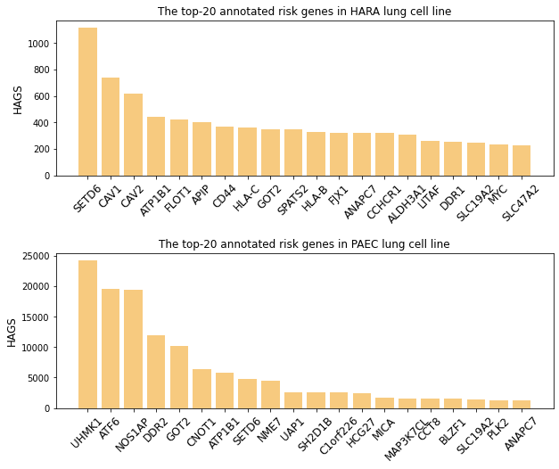

```
['NOS1AP ranked 4179 in HARA cell line', 'KCNH2 ranked 4179 in HARA cell line']
['NOS1AP ranked 3 in PAEC cell line', 'KCNH2 ranked 11729 in PAEC cell line']
```

```python
n_top = 20
df_HARA_scores = df_g_scores_minusLogPMultiBeta.loc['HARA'].sort_values(ascending=False)
df_PAEC_scores = df_g_scores_minusLogPMultiBeta.loc['Pulmonary artery endothelial cells (PAEC)'].sort_values(ascending=False)
HARA_scores = df_HARA_scores.values[:n_top]
PAEC_scores = df_PAEC_scores.values[:n_top]
HARA_genes_names = df_HARA_scores.index.to_list()[:n_top]
PAEC_genes_names = df_PAEC_scores.index.to_list()[:n_top]
x_pos = [i for i, _ in enumerate(HARA_scores)]

plt.figure(figsize=(10,8))
plt.subplot(2, 1, 1)
ax1 = plt.bar(x_pos, HARA_scores, color=np.array([248,203,127])/256)
plt.ylabel("HAGS",fontsize=12)
plt.title("The top-%d annotated risk genes in HARA lung cell line"%n_top,fontsize=12)
ax2 = plt.xticks(x_pos, HARA_genes_names,rotation=45,fontsize=12)

plt.subplot(2, 1, 2)
ax3 = plt.bar(x_pos, PAEC_scores, color=np.array([248,203,127])/256)
plt.ylabel("HAGS",fontsize=12)
plt.title("The top-%d annotated risk genes in PAEC lung cell line"%n_top,fontsize=12)
ax4 = plt.xticks(x_pos, PAEC_genes_names,rotation=45,fontsize=12)
plt.subplots_adjust(hspace=0.5)
plt.show()

genes = ['NOS1AP','KCNH2']
uniq_values = list(set(df_HARA_scores))
uniq_values.sort(reverse=True)
rank_HARA=df_HARA_scores.map(lambda x:uniq_values.index(x)+1)

uniq_values = list(set(df_PAEC_scores))
uniq_values.sort(reverse=True)
rank_PAEC=df_PAEC_scores.map(lambda x:uniq_values.index(x)+1)
print(['%s ranked %d in HARA cell line'%(gene, rank_HARA[gene]) for gene in genes])
print(['%s ranked %d in PAEC cell line'%(gene, rank_PAEC[gene]) for gene in genes])
```

## Annoted GWAS risk genes ranks in heart irrelavant cell lines

- Two risk genes (NOS1AP and KCNH2) have a mean rank of $2229^{th}$ and $2093^{th}$ in other heart irrelevant cell lines.

```python
cell_types = df_g_scores_minusLogPMultiBeta.index.to_list()
heart_cell_types = ['hiPSC-CM','HAEC']
rank_list1, rank_list2 = [],[]
for each in cell_types:
    if each not in heart_cell_types:
        df_scores = df_g_scores_minusLogPMultiBeta.loc[each].sort_values(ascending=False)
        uniq_values = list(set(df_scores))
        uniq_values.sort(reverse=True)
        rank=df_scores.map(lambda x:uniq_values.index(x)+1)
        rank_list1 += [rank[genes[0]]]
        rank_list2 += [rank[genes[1]]]
print('%s has a mean rank of %.1f, median rank of %.1f in heart irrelevant cell lines'%(genes[0],np.mean(rank_list1),np.median(rank_list1)))
print('%s has a mean rank of %.1f, median rank of %.1f in heart irrelevant cell lines'%(genes[1],np.mean(rank_list2),np.median(rank_list2)))
```

```
NOS1AP has a mean rank of 2229.1, median rank of 470.0 in heart irrelevant cell lines
KCNH2 has a mean rank of 2092.8, median rank of 280.0 in heart irrelevant cell lines
```